# Part 1

## Importing libraries

```python
# import all required libraries
import numpy as np
import pandas as pd
import seaborn as sns
import matplotlib.pyplot as plt
from sklearn import metrics
from scipy.stats import zscore
from sklearn.linear_model import LogisticRegression
from sklearn.model_selection import train_test_split
from sklearn.neighbors import KNeighborsClassifier
from sklearn.naive_bayes import GaussianNB
from sklearn import svm
import warnings
warnings.filterwarnings('ignore')
%matplotlib inline
```

## Import and warehouse data:

```python
# Importing all 3 datasets
normal=pd.read_csv('Part1 - Normal.csv')
print(f'The normal dataset has a shape of {normal.shape} and a size of {normal.size}')

typeh=pd.read_csv('Part1 - Type_H.csv')
print(f'The Type H dataset has a shape of {typeh.shape} and a size of {typeh.size}')

types=pd.read_csv('Part1 - Type_S.csv')
print(f'The Type S dataset has a shape of {types.shape} and a size of {types.size}')
```

```
The normal dataset has a shape of (100, 7) and a size of 700
The Type H dataset has a shape of (60, 7) and a size of 420
The Type S dataset has a shape of (150, 7) and a size of 1050
```

```python
# checking data in all 3 datasets
print(normal.head())
print()
print(typeh.head())
print()
print(types.head())
print()
```

```
   P_incidence     P_tilt    L_angle    S_slope    P_radius  S_Degree   Class
0    38.505273  16.964297  35.112814  21.540976  127.632875  7.986683  Normal
1    54.920858  18.968430  51.601455  35.952428  125.846646  2.001642  Normal
2    44.362490   8.945435  46.902096  35.417055  129.220682  4.994195  Normal
3    48.318931  17.452121  48.000000  30.866809  128.980308 -0.910941  Normal
4    45.701789  10.659859  42.577846  35.041929  130.178314 -3.388910  Normal

   P_incidence     P_tilt    L_angle    S_slope    P_radius   S_Degree   Class
0    63.027817  22.552586  39.609117  40.475232   98.672917  -0.254400  Type_H
1    39.056951  10.060991  25.015378  28.995960  114.405425   4.564259  Type_H
2    68.832021  22.218482  50.092194  46.613539  105.985135  -3.530317  Type_H
3    69.297008  24.652878  44.311238  44.644130  101.868495  11.211523  Type_H
4    49.712859   9.652075  28.317406  40.060784  108.168725   7.918501  Type_H

   P_incidence     P_tilt    L_angle    S_slope    P_radius   S_Degree   Class
0    74.377678  32.053104  78.772013  42.324573  143.560690  56.125906  Type_S
1    89.680567  32.704435  83.130732  56.976132  129.955476  92.027277  Type_S
2    44.529051   9.433234  52.000000  35.095817  134.711772  29.106575  Type_S
3    77.690577  21.380645  64.429442  56.309932  114.818751  26.931841  Type_S
4    76.147212  21.936186  82.961502  54.211027  123.932010  10.431972  Type_S
```

Since all 3 datasets have same columns, we will merge all 3 datasets into one using concat

```python
df = pd.concat([normal, typeh, types])
print(f'The final combined dataset has a shape of {df.shape} and a size of {df.size}')
```

```
The final combined dataset has a shape of (310, 7) and a size of 2170
```

```python
df.reset_index(inplace=True)
df.drop('index', inplace=True, axis=1)
```

```python
# checking data in df
df.head()
```

|  | P_incidence | P_tilt | L_angle | S_slope | P_radius | S_Degree | Class |
| --- | --- | --- | --- | --- | --- | --- | --- |
| 0 | 38.505273 | 16.964297 | 35.112814 | 21.540976 | 127.632875 | 7.986683 | Normal |
| 1 | 54.920858 | 18.968430 | 51.601455 | 35.952428 | 125.846646 | 2.001642 | Normal |
| 2 | 44.362490 | 8.945435 | 46.902096 | 35.417055 | 129.220682 | 4.994195 | Normal |
| 3 | 48.318931 | 17.452121 | 48.000000 | 30.866809 | 128.980308 | -0.910941 | Normal |
| 4 | 45.701789 | 10.659859 | 42.577846 | 35.041929 | 130.178314 | -3.388910 | Normal |

## Data cleansing:

```python
#Checking data types of all columns
df.dtypes
```

```
P_incidence    float64
P_tilt         float64
L_angle        float64
S_slope        float64
P_radius       float64
S_Degree       float64
Class           object
dtype: object
```

```python
# Converting Class column to categorical
# all other columns contain numerical values and are of the correct data type and need no changes
df.Class = df['Class'].astype('category')
df.dtypes
```

```
P_incidence     float64
P_tilt          float64
L_angle         float64
S_slope         float64
P_radius        float64
S_Degree        float64
Class          category
dtype: object
```

```python
# Check for null values in the attributes.
df.isna().sum()
```

```
P_incidence    0
P_tilt         0
L_angle        0
S_slope        0
P_radius       0
S_Degree       0
Class          0
dtype: int64
```

**There are no null values in the data frame**

```python
# checking at the various classes of patients
df.Class.value_counts()
```

```
Type_S    133
Normal     73
Type_H     37
Nrmal      27
type_h     23
tp_s       17
Name: Class, dtype: int64
```

```python
# looks like there are some mis-spelled data in the class column.
# we will ensure that all classes are uniformly spelled
df.Class = df.Class.replace('Nrmal','Normal')
df.Class = df.Class.replace('type_h','Type_H')
df.Class = df.Class.replace('tp_s','Type_S')
df.Class.value_counts()
```

```
Type_S    150
Normal    100
Type_H     60
Name: Class, dtype: int64
```

## Data analysis & visualisation:

```python
columns = list(df)[0:-1] # Excluding Outcome column which has only classes
```

```python
for column in columns:
    print(f'{column} has mean {round(df[column].mean(),2)}, median {round(df[column].median(),2)}, range of {round(df[column].min(),2)} to {round(df[column].max(),2)} and a standard deviation of {round(df[column].std(),2)}')
    print()
```

```
P_incidence has mean 60.5, median 58.69, range of 26.15 to 129.83 and a standard deviation of 17.24

P_tilt has mean 17.54, median 16.36, range of -6.55 to 49.43 and a standard deviation of 10.01

L_angle has mean 51.93, median 49.56, range of 14.0 to 125.74 and a standard deviation of 18.55

S_slope has mean 42.95, median 42.4, range of 13.37 to 121.43 and a standard deviation of 13.42

P_radius has mean 117.92, median 118.27, range of 70.08 to 163.07 and a standard deviation of 13.32

S_Degree has mean 26.3, median 11.77, range of -11.06 to 418.54 and a standard deviation of 37.56
```

From above data we can see that almost all columns have similar mean and median values except S_Degree which has a very high standard deviation as compared to others

```
Histogram of all numerical columns
```

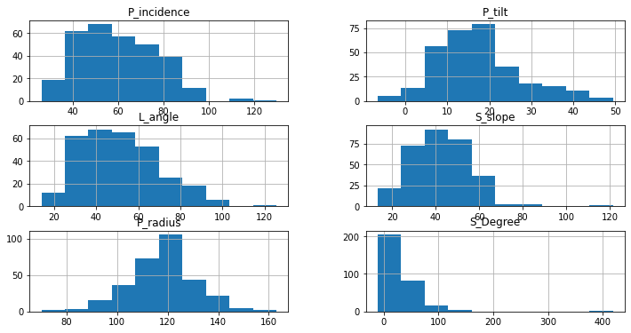

```python
print('Histogram of all numerical columns')
df[columns].hist(stacked=False, figsize=(12,30), layout=(14,2));
```

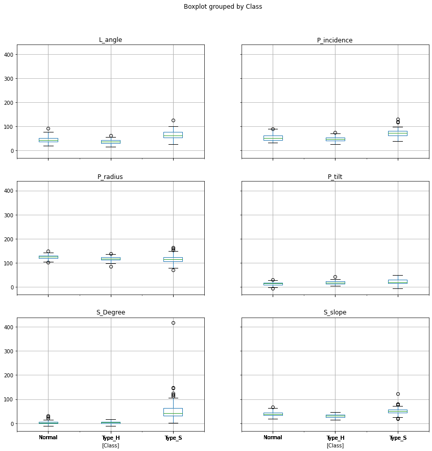

```python
df.boxplot(by='Class',figsize=(14,14));
```

From this plot we can see that:

1. Type S on an average has higher than normal L_angle,S_Slope, S_Degree and P_incidence
2. type H on an average has lower than normal L_angle and S Slope

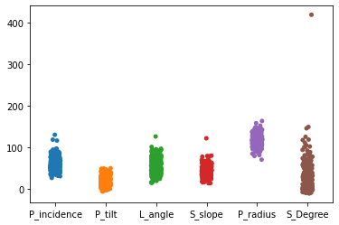

```python
sns.stripplot(data=df)
```

```python
df.corr() # It will show correlation matrix
```

|  | P_incidence | P_tilt | L_angle | S_slope | P_radius | S_Degree |
| --- | --- | --- | --- | --- | --- | --- |
| P_incidence | 1.000000 | 0.629199 | 0.717282 | 0.814960 | -0.247467 | 0.638743 |
| P_tilt | 0.629199 | 1.000000 | 0.432764 | 0.062345 | 0.032668 | 0.397862 |
| L_angle | 0.717282 | 0.432764 | 1.000000 | 0.598387 | -0.080344 | 0.533667 |
| S_slope | 0.814960 | 0.062345 | 0.598387 | 1.000000 | -0.342128 | 0.523557 |
| P_radius | -0.247467 | 0.032668 | -0.080344 | -0.342128 | 1.000000 | -0.026065 |
| S_Degree | 0.638743 | 0.397862 | 0.533667 | 0.523557 | -0.026065 | 1.000000 |

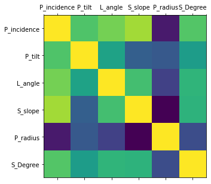

```python
# However we want to see correlation in graphical representation so below is function for that
def plot_corr(df, size=5):
    corr = df.corr()
    fig, ax = plt.subplots(figsize=(size, size))
    ax.matshow(corr)
    plt.xticks(range(len(corr.columns)), corr.columns)
    plt.yticks(range(len(corr.columns)), corr.columns)
plot_corr(df)
```

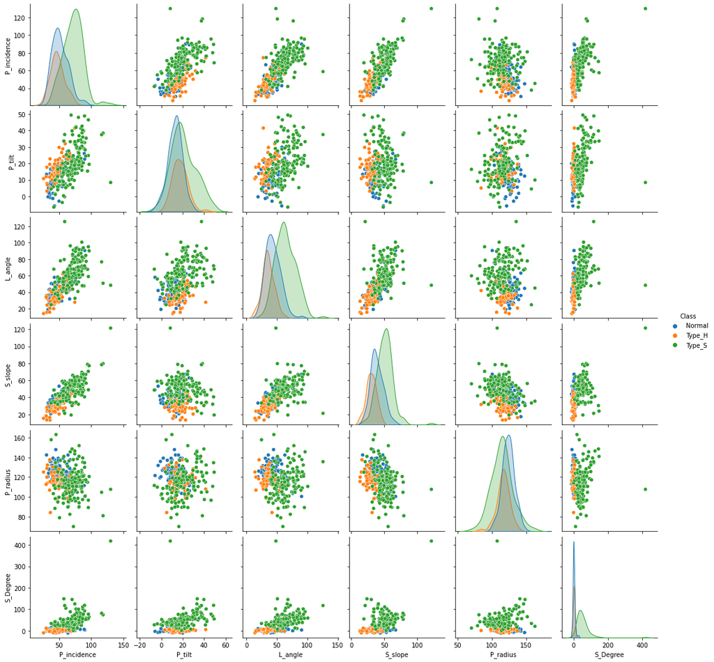

```python
sns.pairplot(df,hue='Class')
```

## Data pre-processing:

```python
# Getting class wise counts to check for target imbalance
n_norm = len(df.loc[df['Class'] == 'Normal'])
n_h = len(df.loc[df['Class'] == 'Type_H'])
n_s = len(df.loc[df['Class'] == 'Type_S'])
total=n_norm + n_h + n_s
print( f'Number of Normal cases: {n_norm}, {round((n_norm / total) * 100) }%' )
print( f'Number of Type H cases: {n_h}, {round((n_h / total) * 100)}%')
print( f'Number of Type s cases: {n_s}, {round((n_s / total) * 100)}%' )
```

```
Number of Normal cases: 100, 32%
Number of Type H cases: 60, 19%
Number of Type s cases: 150, 48%
```

```python
# There is a target imbalance between Type H, Normal and Type S
# Even though there is a target imbalance, it is not a substantial one
# The majority class is Type_S and the minority class is Type_H
```

```python
# balancing all classes
norm_bal=df.loc[df['Class']== 'Normal'][:60]
typeh_bal=df.loc[df['Class']== 'Type_H'][:60]
types_bal=df.loc[df['Class']== 'Type_S'][:60]
df=pd.concat([norm_bal,typeh_bal,types_bal])
df.Class.value_counts()
```

```
Normal    60
Type_H    60
Type_S    60
Name: Class, dtype: int64
```

```python
#Segregate predictors vs target attributes
features=df.drop('Class', axis=1)
print(features.head())

print()

labels=df.Class
print(labels.head())
```

```
   P_incidence     P_tilt    L_angle    S_slope    P_radius  S_Degree
0    38.505273  16.964297  35.112814  21.540976  127.632875  7.986683
1    54.920858  18.968430  51.601455  35.952428  125.846646  2.001642
2    44.362490   8.945435  46.902096  35.417055  129.220682  4.994195
3    48.318931  17.452121  48.000000  30.866809  128.980308 -0.910941
4    45.701789  10.659859  42.577846  35.041929  130.178314 -3.388910

0    Normal
1    Normal
2    Normal
3    Normal
4    Normal
Name: Class, dtype: category
Categories (3, object): ['Normal', 'Type_H', 'Type_S']
```

```python
# normalising all columns
# convert the features into z scores as we do not know what units / scales were used and store them in new dataframe

XScaled  = features.apply(zscore)  # convert all attributes to Z scale
XScaled.describe().T
```

|  | count | mean | std | min | 25% | 50% | 75% | max |
| --- | --- | --- | --- | --- | --- | --- | --- | --- |
| P_incidence | 180.0 | -1.634495e-17 | 1.002789 | -1.884611 | -0.772159 | -0.141592 | 0.711401 | 4.415115 |
| P_tilt | 180.0 | 2.237408e-16 | 1.002789 | -2.679241 | -0.721294 | -0.073675 | 0.542344 | 2.856559 |
| L_angle | 180.0 | 6.550316e-16 | 1.002789 | -2.052837 | -0.732131 | -0.082658 | 0.642057 | 2.840363 |
| S_slope | 180.0 | 2.198858e-16 | 1.002789 | -1.968970 | -0.687670 | -0.147730 | 0.634603 | 6.011127 |
| P_radius | 180.0 | -1.538892e-15 | 1.002789 | -3.180011 | -0.585084 | -0.047086 | 0.549959 | 3.734208 |
| S_Degree | 180.0 | -4.286694e-17 | 1.002789 | -0.761129 | -0.477243 | -0.352726 | 0.177194 | 9.679150 |

```python
# Split X and y into training and test set in 70:30 ratio
X_train, X_test, y_train, y_test = train_test_split(XScaled, labels, test_size=0.30, random_state=1)
```

```python
y_train.value_counts()
```

```
Type_S    45
Type_H    44
Normal    37
Name: Class, dtype: int64
```

## Model training, testing and tuning:

```python
NNH = KNeighborsClassifier(n_neighbors= 5 , weights = 'distance' )
```

```python
# training Nearest Neighbour algorithm
NNH.fit(X_train, y_train)
```

```
KNeighborsClassifier(weights='distance')
```

```python
print(f'accuracy of the model on training set is {NNH.score(X_train, y_train)*100}%')
```

```
accuracy of the model on training set is 100.0%
```

```python
predicted_labels = NNH.predict(X_test)
print(f'accuracy of the model on testing set is {NNH.score(X_test, y_test)*100}%')
```

```
accuracy of the model on testing set is 74.07407407407408%
```

```
Confusion Matrix
```

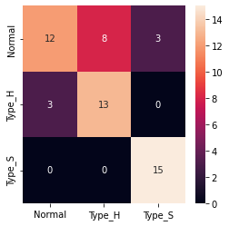

```python
# calculate accuracy measures and confusion matrix


print("Confusion Matrix")
cm=metrics.confusion_matrix(y_test, predicted_labels, labels=['Normal','Type_H','Type_S'])

df_cm = pd.DataFrame(cm, index = [i for i in ['Normal','Type_H','Type_S']],
                  columns = [i for i in ['Normal','Type_H','Type_S']])
plt.figure(figsize = (4,4))
sns.heatmap(df_cm, annot=True);
```

a. 12, 13 and 15 patients got classified correctly as Normal, Type H and Type S respectively

b. 3 Type H got mis-classified as Normal

c. 8 Normal got mis-classified as Type H

d. 3 Normal got misclassified as Type S

e. Normal class saw maximum mis-classifications

f. Type S class saw no mis-classifications

```python
print("Classification Report")
print(metrics.classification_report(y_test, predicted_labels, labels=['Normal','Type_H','Type_S']))
```

```
Classification Report
              precision    recall  f1-score   support

      Normal       0.80      0.52      0.63        23
      Type_H       0.62      0.81      0.70        16
      Type_S       0.83      1.00      0.91        15

    accuracy                           0.74        54
   macro avg       0.75      0.78      0.75        54
weighted avg       0.76      0.74      0.73        54
```

```python
# automation for finding best k value that gives max accuracy in test data
scores =[]
for k in range(1,50):
    NNH = KNeighborsClassifier(n_neighbors = k, weights = 'distance' )
    NNH.fit(X_train, y_train)
    scores.append(NNH.score(X_test, y_test))


print(f'highest accuracy is obtained for k = {np.argmax(scores)+1} with score = {scores[np.argmax(scores)]*100}%')
```

```
highest accuracy is obtained for k = 3 with score = 79.62962962962963%
```

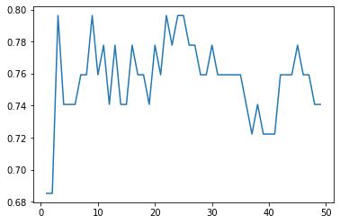

```python
plt.plot(range(1,50),scores);
```

```python
# Apply all the possible tuning techniques to train the best model for the given data. Select the final best trained model with
# your comments for selecting this model.

# creating the following models : knn, naive bayes, logistic regression, svm
# and selecting the best model from it
model_log = LogisticRegression(solver="liblinear")
model_log.fit(X_train, y_train)

model_knn = KNeighborsClassifier(n_neighbors= 3 , weights = 'distance' )
model_knn.fit(X_train, y_train)

model_nb = GaussianNB()
model_nb.fit(X_train, y_train)

model_svm = svm.SVC(gamma=0.025, C=3)
model_svm.fit(X_train, y_train)
```

```
SVC(C=3, gamma=0.025)
```

```python
models=[model_log,model_knn,model_nb,model_svm]

for model in models:
    print(f'{model} has a score of {model.score(X_test,y_test)*100}')
    print()
```

```
LogisticRegression(solver='liblinear') has a score of 87.03703703703704

KNeighborsClassifier(n_neighbors=3, weights='distance') has a score of 79.62962962962963

GaussianNB() has a score of 75.92592592592592

SVC(C=3, gamma=0.025) has a score of 81.48148148148148
```

```python
# Therefore the best model is Logistic regression because of its high accuracy in test data
```

## Conclusion and improvisation:

```python
# Write your conclusion on the results.
```

knn is able to successfully predict the condition with an accuracy of 79.62%. However other models are better suited like logistic regression

the model has a recall score of 1 for type s condition and would be ideal to predict this condition

```python
# Detailed suggestions or improvements or on quality, quantity, variety, velocity, veracity etc. on the data points
# collected by the research team to perform a better data analysis in future.
```

1. no units were mentioned regarding all the parameters
2. more context could be given regarding the condition and what exact measurements are being taken
3. many classes in target column were mis spelled. This could be avoided

# Part 2

## Import and warehouse data:

```python
# import both the datasets

data1= pd.read_csv('Part2 - Data1.csv')
print(f' data1 has a shape of {data1.shape} and a size of {data1.size}')

data2=pd.read_csv('Part2 -Data2.csv')
print(f' data2 has a shape of {data2.shape} and a size of {data2.size}')
```

```
 data1 has a shape of (5000, 8) and a size of 40000
 data2 has a shape of (5000, 7) and a size of 35000
```

```python
data1.head()
```

|  | ID | Age | CustomerSince | HighestSpend | ZipCode | HiddenScore | MonthlyAverageSpend | Level |
| --- | --- | --- | --- | --- | --- | --- | --- | --- |
| 0 | 1 | 25 | 1 | 49 | 91107 | 4 | 1.6 | 1 |
| 1 | 2 | 45 | 19 | 34 | 90089 | 3 | 1.5 | 1 |
| 2 | 3 | 39 | 15 | 11 | 94720 | 1 | 1.0 | 1 |
| 3 | 4 | 35 | 9 | 100 | 94112 | 1 | 2.7 | 2 |
| 4 | 5 | 35 | 8 | 45 | 91330 | 4 | 1.0 | 2 |

```python
data2.head()
```

|  | ID | Mortgage | Security | FixedDepositAccount | InternetBanking | CreditCard | LoanOnCard |
| --- | --- | --- | --- | --- | --- | --- | --- |
| 0 | 1 | 0 | 1 | 0 | 0 | 0 | NaN |
| 1 | 2 | 0 | 1 | 0 | 0 | 0 | NaN |
| 2 | 3 | 0 | 0 | 0 | 0 | 0 | NaN |
| 3 | 4 | 0 | 0 | 0 | 0 | 0 | NaN |
| 4 | 5 | 0 | 0 | 0 | 0 | 1 | NaN |

Since both datasets seem to be of the same customers (based on ID column), we will merge them using the merge method on ID column

```python
# merging both datasets

data= pd.merge(left=data1, right=data2, on='ID')
print(f' data has a shape of {data.shape} and a size of {data.size}')

data.head()
```

```
 data has a shape of (5000, 14) and a size of 70000
```

|  | ID | Age | CustomerSince | HighestSpend | ZipCode | HiddenScore | MonthlyAverageSpend | Level | Mortgage | Security | FixedDepositAccount | InternetBanking | CreditCard | LoanOnCard |
| --- | --- | --- | --- | --- | --- | --- | --- | --- | --- | --- | --- | --- | --- | --- |
| 0 | 1 | 25 | 1 | 49 | 91107 | 4 | 1.6 | 1 | 0 | 1 | 0 | 0 | 0 | NaN |
| 1 | 2 | 45 | 19 | 34 | 90089 | 3 | 1.5 | 1 | 0 | 1 | 0 | 0 | 0 | NaN |
| 2 | 3 | 39 | 15 | 11 | 94720 | 1 | 1.0 | 1 | 0 | 0 | 0 | 0 | 0 | NaN |
| 3 | 4 | 35 | 9 | 100 | 94112 | 1 | 2.7 | 2 | 0 | 0 | 0 | 0 | 0 | NaN |
| 4 | 5 | 35 | 8 | 45 | 91330 | 4 | 1.0 | 2 | 0 | 0 | 0 | 0 | 1 | NaN |

Since Id has no significance in training, we will set it as the index and drop the column

```python
data.set_index(data.ID,inplace=True)
data.drop('ID', axis=1, inplace=True)
data.head()
```

| ID | Age | CustomerSince | HighestSpend | ZipCode | HiddenScore | MonthlyAverageSpend | Level | Mortgage | Security | FixedDepositAccount | InternetBanking | CreditCard | LoanOnCard |
| --- | --- | --- | --- | --- | --- | --- | --- | --- | --- | --- | --- | --- | --- |
| 1 | 25 | 1 | 49 | 91107 | 4 | 1.6 | 1 | 0 | 1 | 0 | 0 | 0 | NaN |
| 2 | 45 | 19 | 34 | 90089 | 3 | 1.5 | 1 | 0 | 1 | 0 | 0 | 0 | NaN |
| 3 | 39 | 15 | 11 | 94720 | 1 | 1.0 | 1 | 0 | 0 | 0 | 0 | 0 | NaN |
| 4 | 35 | 9 | 100 | 94112 | 1 | 2.7 | 2 | 0 | 0 | 0 | 0 | 0 | NaN |
| 5 | 35 | 8 | 45 | 91330 | 4 | 1.0 | 2 | 0 | 0 | 0 | 0 | 1 | NaN |

## Data cleansing:

```python
# Checking the data types of all columns
data.dtypes
```

```
Age                      int64
CustomerSince            int64
HighestSpend             int64
ZipCode                  int64
HiddenScore              int64
MonthlyAverageSpend    float64
Level                    int64
Mortgage                 int64
Security                 int64
FixedDepositAccount      int64
InternetBanking          int64
CreditCard               int64
LoanOnCard             float64
dtype: object
```

```python
# many of the columns seem to have the wrong datatype, however we will correct it later
```

```python
#Checking for null values
data.isna().sum()
```

```
Age                     0
CustomerSince           0
HighestSpend            0
ZipCode                 0
HiddenScore             0
MonthlyAverageSpend     0
Level                   0
Mortgage                0
Security                0
FixedDepositAccount     0
InternetBanking         0
CreditCard              0
LoanOnCard             20
dtype: int64
```

LoanOnCard column has 20 null values. We will assume these null values as no loan and hence replace them with 0

```python
data.LoanOnCard.fillna(0,inplace=True)
```

```python
# looking at the data statistics to infer type of data in each column
```

```python
data.describe().T
```

|  | count | mean | std | min | 25% | 50% | 75% | max |
| --- | --- | --- | --- | --- | --- | --- | --- | --- |
| Age | 5000.0 | 45.338400 | 11.463166 | 23.0 | 35.0 | 45.0 | 55.0 | 67.0 |
| CustomerSince | 5000.0 | 20.104600 | 11.467954 | -3.0 | 10.0 | 20.0 | 30.0 | 43.0 |
| HighestSpend | 5000.0 | 73.774200 | 46.033729 | 8.0 | 39.0 | 64.0 | 98.0 | 224.0 |
| ZipCode | 5000.0 | 93152.503000 | 2121.852197 | 9307.0 | 91911.0 | 93437.0 | 94608.0 | 96651.0 |
| HiddenScore | 5000.0 | 2.396400 | 1.147663 | 1.0 | 1.0 | 2.0 | 3.0 | 4.0 |
| MonthlyAverageSpend | 5000.0 | 1.937938 | 1.747659 | 0.0 | 0.7 | 1.5 | 2.5 | 10.0 |
| Level | 5000.0 | 1.881000 | 0.839869 | 1.0 | 1.0 | 2.0 | 3.0 | 3.0 |
| Mortgage | 5000.0 | 56.498800 | 101.713802 | 0.0 | 0.0 | 0.0 | 101.0 | 635.0 |
| Security | 5000.0 | 0.104400 | 0.305809 | 0.0 | 0.0 | 0.0 | 0.0 | 1.0 |
| FixedDepositAccount | 5000.0 | 0.060400 | 0.238250 | 0.0 | 0.0 | 0.0 | 0.0 | 1.0 |
| InternetBanking | 5000.0 | 0.596800 | 0.490589 | 0.0 | 0.0 | 1.0 | 1.0 | 1.0 |
| CreditCard | 5000.0 | 0.294000 | 0.455637 | 0.0 | 0.0 | 0.0 | 1.0 | 1.0 |
| LoanOnCard | 5000.0 | 0.096000 | 0.294621 | 0.0 | 0.0 | 0.0 | 0.0 | 1.0 |

```python
for column in data.columns:
    print(column, len(data[column].unique()))
```

```
Age 45
CustomerSince 47
HighestSpend 162
ZipCode 467
HiddenScore 4
MonthlyAverageSpend 108
Level 3
Mortgage 347
Security 2
FixedDepositAccount 2
InternetBanking 2
CreditCard 2
LoanOnCard 2
```

from above 2 cells we can infer that the following columns are binary categorical

Security, FixedDepositAccount, InternetBanking, CreditCard, LoanOnCard.

Also Level and HiddenScore columns are ordinal

ZipCode column is categorical

```python
#changing columns to its correct data types

for column in ['Security', 'FixedDepositAccount', 'InternetBanking', 'CreditCard', 'LoanOnCard']:
    data[column]=data[column].astype('bool')

data['ZipCode'] = data['ZipCode'].astype('category')
data['HiddenScore'] = pd.Categorical(data['HiddenScore'],categories=[1.0,2.0,3.0,4.0], ordered=True)
data['Level'] = pd.Categorical(data['Level'],categories=[1.0,2.0,3.0], ordered=True)
data.dtypes
```

```
Age                       int64
CustomerSince             int64
HighestSpend              int64
ZipCode                category
HiddenScore            category
MonthlyAverageSpend     float64
Level                  category
Mortgage                  int64
Security                   bool
FixedDepositAccount        bool
InternetBanking            bool
CreditCard                 bool
LoanOnCard                 bool
dtype: object
```

## Data analysis & visualisation:

```python
 # including only numerical columns
num_cols = ['Age','CustomerSince','HighestSpend','MonthlyAverageSpend','Mortgage']

 # including only categorical/boolean columns
cat_cols = ['ZipCode', 'HiddenScore','Level', 'Security','FixedDepositAccount', 'InternetBanking', 'CreditCard', 'LoanOnCard']
```

```python
for column in num_cols:
    print(f'{column} has mean {round(data[column].mean(),2)}, median {round(data[column].median(),2)}, range of {round(data[column].min(),2)} to {round(data[column].max(),2)} and a standard deviation of {round(data[column].std(),2)}')
    print()
```

```
Age has mean 45.34, median 45.0, range of 23 to 67 and a standard deviation of 11.46

CustomerSince has mean 20.1, median 20.0, range of -3 to 43 and a standard deviation of 11.47

HighestSpend has mean 73.77, median 64.0, range of 8 to 224 and a standard deviation of 46.03

MonthlyAverageSpend has mean 1.94, median 1.5, range of 0.0 to 10.0 and a standard deviation of 1.75

Mortgage has mean 56.5, median 0.0, range of 0 to 635 and a standard deviation of 101.71
```

```
Histogram of all numerical columns
```

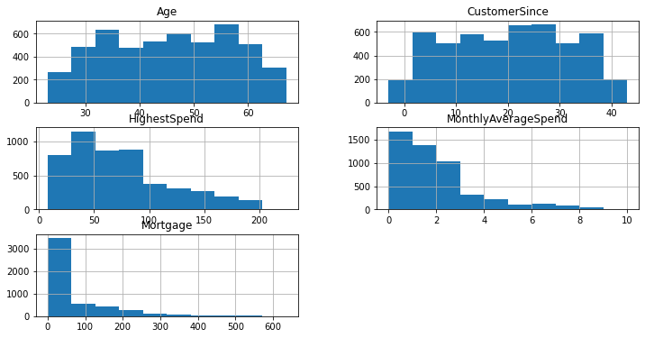

```python
print('Histogram of all numerical columns')
data.hist(stacked=False, figsize=(12,30), layout=(14,2));
```

We can see that HighestSpend, MonthlyAverageSpend and Mortgage are right skewed

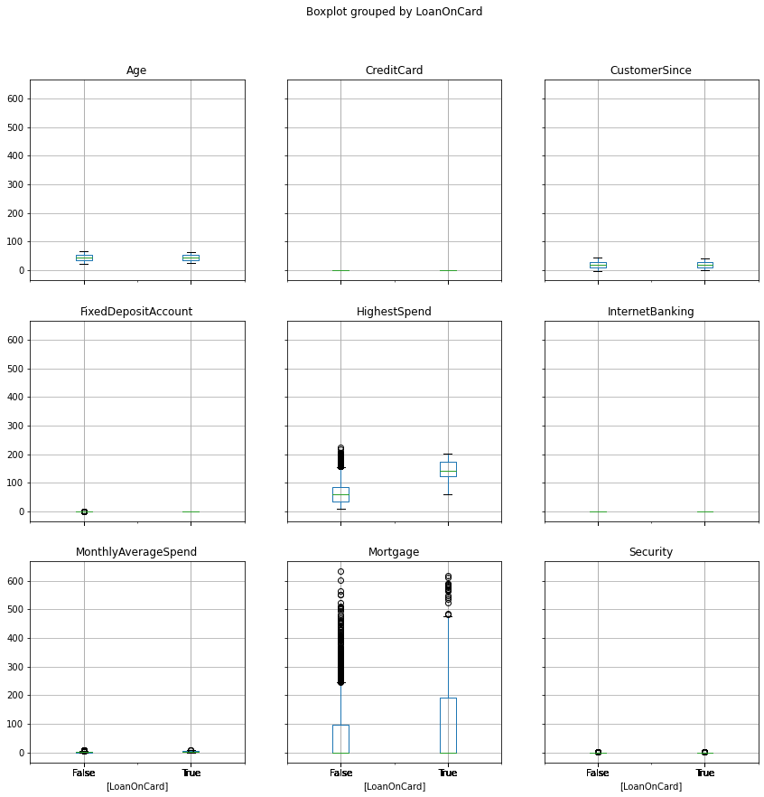

```python
data.boxplot(by='LoanOnCard',figsize=(14,14));
```

From this we can see that people with LoanOnCard tend to have higher values in Mortgage and HighestSpend

```python
data.corr() # It will show correlation matrix
```

|  | Age | CustomerSince | HighestSpend | MonthlyAverageSpend | Mortgage | Security | FixedDepositAccount | InternetBanking | CreditCard | LoanOnCard |
| --- | --- | --- | --- | --- | --- | --- | --- | --- | --- | --- |
| Age | 1.000000 | 0.994215 | -0.055269 | -0.052012 | -0.012539 | -0.000436 | 0.008043 | 0.013702 | 0.007681 | -0.007726 |
| CustomerSince | 0.994215 | 1.000000 | -0.046574 | -0.050077 | -0.010582 | -0.001232 | 0.010353 | 0.013898 | 0.008967 | -0.007413 |
| HighestSpend | -0.055269 | -0.046574 | 1.000000 | 0.645984 | 0.206806 | -0.002616 | 0.169738 | 0.014206 | -0.002385 | 0.502462 |
| MonthlyAverageSpend | -0.052012 | -0.050077 | 0.645984 | 1.000000 | 0.109905 | 0.015086 | 0.136534 | -0.003611 | -0.006689 | 0.366889 |
| Mortgage | -0.012539 | -0.010582 | 0.206806 | 0.109905 | 1.000000 | -0.005411 | 0.089311 | -0.005995 | -0.007231 | 0.142095 |
| Security | -0.000436 | -0.001232 | -0.002616 | 0.015086 | -0.005411 | 1.000000 | 0.317034 | 0.012627 | -0.015028 | 0.021954 |
| FixedDepositAccount | 0.008043 | 0.010353 | 0.169738 | 0.136534 | 0.089311 | 0.317034 | 1.000000 | 0.175880 | 0.278644 | 0.316355 |
| InternetBanking | 0.013702 | 0.013898 | 0.014206 | -0.003611 | -0.005995 | 0.012627 | 0.175880 | 1.000000 | 0.004210 | 0.006278 |
| CreditCard | 0.007681 | 0.008967 | -0.002385 | -0.006689 | -0.007231 | -0.015028 | 0.278644 | 0.004210 | 1.000000 | 0.002802 |
| LoanOnCard | -0.007726 | -0.007413 | 0.502462 | 0.366889 | 0.142095 | 0.021954 | 0.316355 | 0.006278 | 0.002802 | 1.000000 |

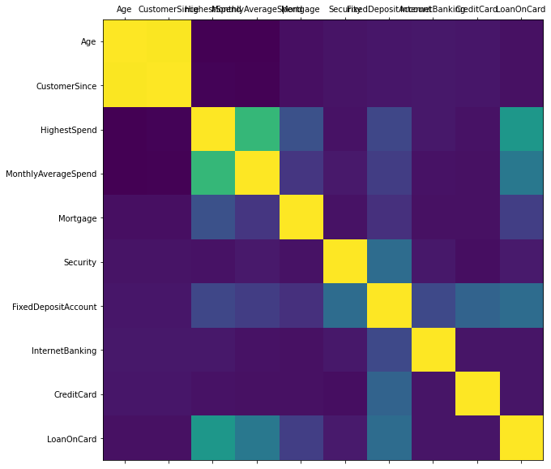

```python
# However we want to see correlation in graphical representation so below is function for that
def plot_corr(df, size=10):
    corr = df.corr()
    fig, ax = plt.subplots(figsize=(size, size))
    ax.matshow(corr)
    plt.xticks(range(len(corr.columns)), corr.columns)
    plt.yticks(range(len(corr.columns)), corr.columns)
plot_corr(data)
```

We can see that age and customersince columns have very high correlation

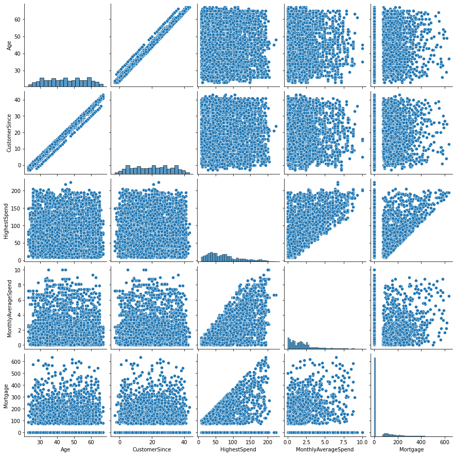

```python
sns.pairplot(data[num_cols])
```

1. Age and Customer since is directly related
2. people with low Highest spend dont have high mortgages

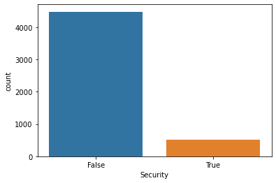

```python
sns.countplot(data['Security']);
```

very few customers have security at the bank

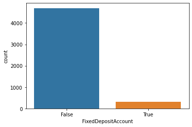

```python
sns.countplot(data['FixedDepositAccount']);
```

very few customers have Fixed deposit account at the bank

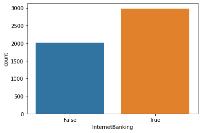

```python
sns.countplot(data['InternetBanking']);
```

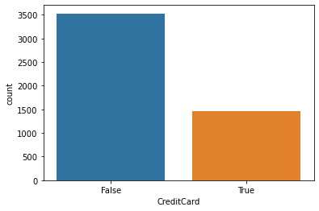

```python
sns.countplot(data['CreditCard']);
```

substantial number of customers do not have a credit card

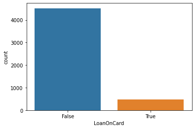

```python
sns.countplot(data['LoanOnCard']);
```

hardly any customers have loan on card